# HDAT9600 Final Assignment

# Task 2 (15 marks)

In this task, you are required to develop a Cox proportional hazards survival model using the `icu_patients_df1` data set which adequately explains or predicts the length of survival indicated by the `Days` variable, with censoring as indicated by the `Status` variable. You should fit a series of models, maybe three or four, evaluating each one, before you present your final model. Your final model should **not** include all the predictor variables, just a small subset of them, which you have selected based on statistical significance and/or background knowledge. Aim for between five and ten predictor variables (slightly more or fewer is OK). It is perfectly acceptable to include predictor variables in your final model which are not statistically significant, as long as you justify their inclusion on medical or physiological grounds (you will not be marked down if your medical justification is not exactly correct, but do you best). You should assess each model you consider for goodness of fit and other relevant statistics, and you should assess your final model for violations of assumptions and perform other diagnostics which you think are relevant (and modify the model if indicated, or at comment on the possible impact of what your diagnostics show). Finally, re-fit your final model to the unimputed data frame (`icu_patients_df0.rds`) and comment on any differences you find.

### Hints

1. Select an initial subset of explanatory variables that you will use to predict survival. Justify your choice.
2. Conduct basic exploratory data analysis on your variables of choice.
3. Fit appropriate univariate Cox proportional hazards models.
4. Fit an appropriate series of multivariable Cox proportional hazards models, justifying your approach. Assess each model you consider for goodness of fit and other relevant statistics.
5. Present your final model. Your final model should **not** include all the predictor variables, just a small subset of them, which you have selected based on statistical significance and/or background knowledge.
6. For your final model, present a set of diagnostic statistics and/or charts and comment on them.
7. Write a very brief paragraph summarising the most important findings of your final model. Include the most important values from the statistical output, and a simple clinical interpretation.

**Create your response to this task here, as a mixture of embedded (`knitr`) R code and any resulting outputs, and explanatory or commentary text.**

```r
library(survival)
library(rankhazard)
library(survminer)
library(eha)
```

### Task 2 Part 1

### Variable selection

As discussed prevously, the variable SOFA appears to be unreliable - so we will not use this in our analysis. We will include the SAPS1 score, since it includes information from a range of the variables, reducing the need to include them in our model.

The SAPS score is based on the following variables - Age, HR, SBP, Temp, RR, urine, BUN, HCT, WBC, glucose, potassium, sodium, HCO3, GCS. It looks at max/min values rather than any changes in measurements, i.e. the "_diff" variables may have some extra useful information.

We will include Age, Gender and ICUType since these are important demographic characteristics.

We will include Na_diff, K_diff and pH_diff - since large changes in these variables may be a sign of poor prognosis. Lactate_max, HCO3_min, PaO2_min, BUN_max are also markers of poor prognosis.

We will include TroponinI_max, since it is a marker of cardiac tissue damage. Cholesterol_max may be a longer term factor - include it in initial analysis. Also include WBC_min and Platelets_min as low counts may be a relevant marker.

Initial subset of 15 variables: “SAPS1”, “Age”, “Gender”, “ICUType”, “Na_diff”, “K_diff”, “pH_diff”, “Lactate_max”, “HCO3_min”, “PaO2_min”, “BUN_max”, “TroponinI_max”, “Cholesterol_max”, “WBC_min”, “Platelets_min”

```r
# Create list of required variables
var.list2 <- c("SAPS1", "Age", "Gender", "ICUType", "Na_diff", "K_diff", "pH_diff", "Lactate_max", "HCO3_min", "PaO2_min", "BUN_max", "TroponinI_max", "Cholesterol_max", "WBC_min", "Platelets_min")

# Create dataframe with the required variables, eliminating any observations with NA's
ICUSurv <- icu_patients_df1[, c("in_hospital_death", "Days", "Status", var.list2)]
ICUSurv <- ICUSurv[complete.cases(ICUSurv),]

str(ICUSurv)
```

```
## 'data.frame':    1965 obs. of  18 variables:
##  $ in_hospital_death: num  0 0 0 0 0 0 0 1 0 0 ...
##  $ Days             : num  2408 2408 2408 575 918 ...
##  $ Status           : logi  FALSE FALSE FALSE TRUE TRUE TRUE ...
##  $ SAPS1            : num  6 16 21 7 17 14 14 19 11 14 ...
##  $ Age              : num  54 76 44 68 88 64 68 78 64 74 ...
##  $ Gender           : Factor w/ 2 levels "Female","Male": 1 2 1 2 1 2 1 1 1 2 ...
##  $ ICUType          : Factor w/ 4 levels "Coronary Care Unit",..: 4 2 3 3 3 1 3 3 3 2 ...
##  $ Na_diff          : num  2.207 0.207 2.207 1.793 0.793 ...
##  $ K_diff           : num  0.265 0.165 4.465 0.135 1.865 ...
##  $ pH_diff          : num  0.1201 0.0801 0.1401 0.1401 0.0401 ...
##  $ Lactate_max      : num  1.9 2.9 1.9 1.5 2 1.3 1.1 2 11.8 3.1 ...
##  $ HCO3_min         : num  26 21 24 27 18 19 23 11 21 23 ...
##  $ PaO2_min         : num  111 89 65 64 78 78 99 88 47 102 ...
##  $ BUN_max          : num  13 18 8 23 45 19 32 81 21 19 ...
##  $ TroponinI_max    : num  1 31.7 36.7 6.3 5.6 1.3 0.8 3.5 42.9 3.9 ...
##  $ Cholesterol_max  : num  154 139 111 127 104 212 175 100 187 125 ...
##  $ WBC_min          : num  11.2 7.4 3.7 8.8 3.8 14.4 6.2 16.1 15.2 9 ...
##  $ Platelets_min    : num  221 164 72 315 109 219 325 91 696 139 ...
```

### Task 2 Part 2

### EDA

```r
summary(ICUSurv)
```

```
##  in_hospital_death      Days        Status            SAPS1            Age           Gender
##  Min.   :0.000     Min.   :   1   Mode :logical   Min.   : 1.00   Min.   :16.00   Female: 865
##  1st Qu.:0.000     1st Qu.: 252   FALSE:1224      1st Qu.:11.00   1st Qu.:53.00   Male  :1100
##  Median :0.000     Median :2408   TRUE :741       Median :15.00   Median :67.00
##  Mean   :0.145     Mean   :1629                   Mean   :14.96   Mean   :64.54
##  3rd Qu.:0.000     3rd Qu.:2408                   3rd Qu.:19.00   3rd Qu.:78.00
##  Max.   :1.000     Max.   :2408                   Max.   :34.00   Max.   :90.00
##                           ICUType       Na_diff            K_diff            pH_diff          Lactate_max
##  Coronary Care Unit           :289   Min.   : 0.2066   Min.   : 0.03521   Min.   :0.000114   Min.   : 0.400
##  Cardiac Surgery Recovery Unit:436   1st Qu.: 1.7934   1st Qu.: 0.33521   1st Qu.:0.059886   1st Qu.: 1.600
##  Medical ICU                  :724   Median : 3.2066   Median : 0.56479   Median :0.089886   Median : 2.300
##  Surgical ICU                 :516   Mean   : 4.1018   Mean   : 0.68806   Mean   :0.099094   Mean   : 2.895
##                                      3rd Qu.: 5.2066   3rd Qu.: 0.86479   3rd Qu.:0.120114   3rd Qu.: 3.400
##                                      Max.   :41.2066   Max.   :18.76479   Max.   :4.369886   Max.   :29.300
##     HCO3_min        PaO2_min        BUN_max       TroponinI_max   Cholesterol_max    WBC_min       Platelets_min
##  Min.   : 5.00   Min.   : 20.0   Min.   :  3.00   Min.   : 0.30   Min.   : 59     Min.   :  0.10   Min.   :  9.0
##  1st Qu.:20.00   1st Qu.: 73.0   1st Qu.: 14.00   1st Qu.: 4.60   1st Qu.:122     1st Qu.:  7.70   1st Qu.:126.0
##  Median :23.00   Median : 91.0   Median : 20.00   Median :10.70   Median :155     Median : 10.40   Median :183.0
##  Mean   :22.41   Mean   :103.4   Mean   : 26.96   Mean   :13.13   Mean   :157     Mean   : 11.52   Mean   :197.2
##  3rd Qu.:25.00   3rd Qu.:120.0   3rd Qu.: 33.00   3rd Qu.:17.60   3rd Qu.:184     3rd Qu.: 14.10   3rd Qu.:245.0
##  Max.   :44.00   Max.   :477.0   Max.   :197.00   Max.   :43.40   Max.   :330     Max.   :128.30   Max.   :891.0
```

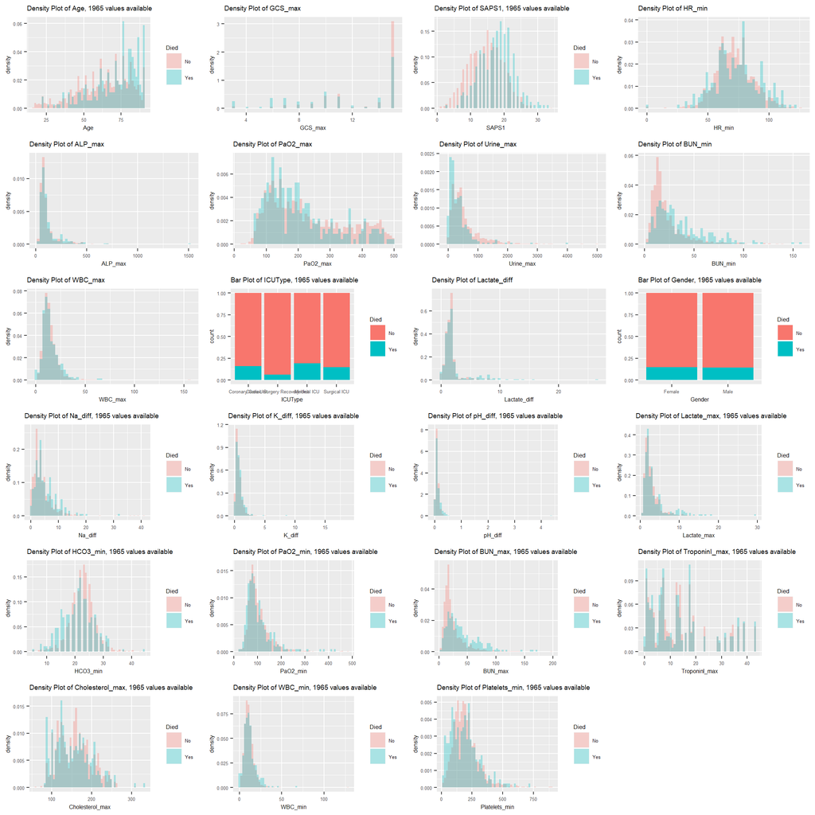

```r
#density plots for reviewing variables based on outcome
#Create empty list to store plots
plot_list2 <- list()
for (i in names(ICUSurv)[4:18]){

  if(is.numeric(ICUSurv[[i]])){

    plot_list[[i]] <- ggplot(ICUSurv, aes_string(i)) +
          geom_histogram(aes(y = ..density.., fill = factor(in_hospital_death, labels = c("No","Yes"))), alpha = .3, bins = 60, position = "identity") +
          labs(x=i, fill="Died", title = paste0("Density Plot of ", i,", ", length(na.omit(ICUSurv[[i]]))," values available")) +
      theme(text = element_text(size=6))

    }else{

    plot_list[[i]] <- ggplot(ICUSurv, aes_string(i)) +
          geom_bar(position = "fill", aes(fill=factor(in_hospital_death, labels = c("No", "Yes")))) +
          labs(x = i, fill = "Died", title = paste0("Bar Plot of ", i,", ",  length(na.omit(ICUSurv[[i]])), " values available")) +
      theme(text = element_text(size=6))

  }
}


n <- length(plot_list)
nCol <- 4
do.call("grid.arrange", c(plot_list, ncol=nCol))
```

Kaplan-Meier and Nelson-Aalen curves for our data are plotted below.

```r
# Plot the overall Kaplan-Meier survival curve for the data
hd_fit <- survfit( Surv(Days,Status) ~ 1, data = ICUSurv)

# plotting Kaplan-Meier estimate
plot(hd_fit, main = 'Kaplan-Meier estimate of survival function', xlab = 'Days')


# get the mean and median survival times
print(hd_fit, print.rmean = TRUE)
```

```
## Call: survfit(formula = Surv(Days, Status) ~ 1, data = ICUSurv)
##
##          n     events     *rmean *se(rmean)     median    0.95LCL    0.95UCL
##     1965.0      741.0     1629.4       23.7         NA         NA         NA
##     * restricted mean with upper limit =  2408
```

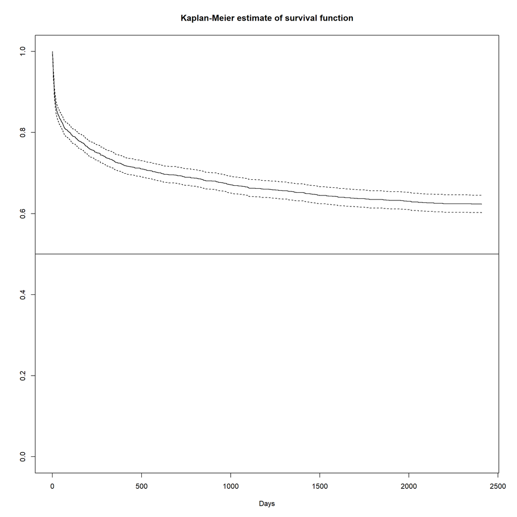

```r
# plot the median survival time
plot(hd_fit, main = 'Kaplan-Meier estimate of survival function', xlab = 'Days')
abline(a = 0.5, b = 0)
```

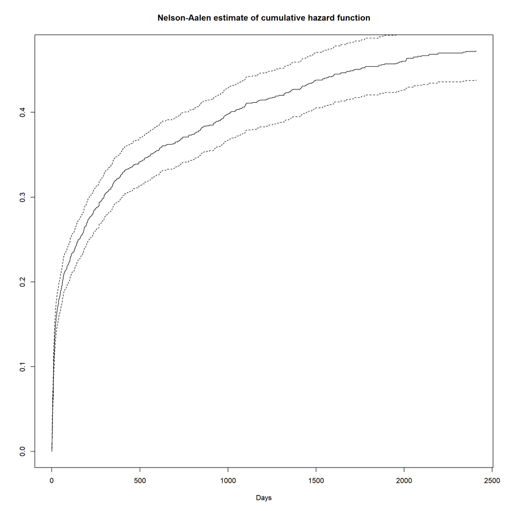

```r
# plotting Nelson-Aalen estimate
plot(hd_fit, fun="cumhaz", main = "Nelson-Aalen estimate of cumulative hazard function", xlab = "Days")
```

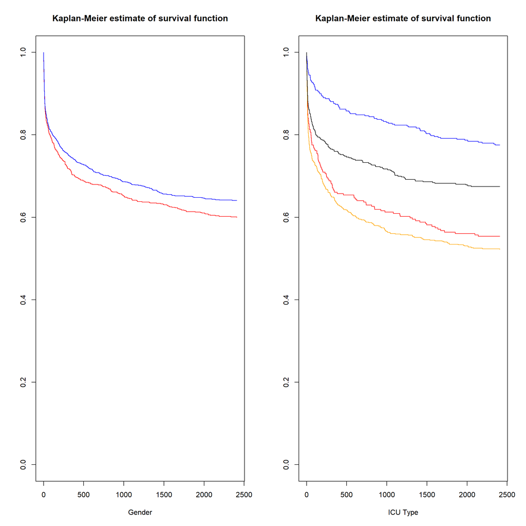

```r
par(mfrow=c(1,2))
# plot the Kaplan-Meier survival curves by the categorical variables
hd_fitbyGender <- survfit( Surv(Days,Status) ~ Gender, data = ICUSurv)
plot(hd_fitbyGender, main = 'Kaplan-Meier estimate of survival function', xlab = 'Gender',col = c("red","blue"))

hd_fitbytype <- survfit( Surv(Days,Status) ~ ICUType, data = ICUSurv)
plot(hd_fitbytype, main = 'Kaplan-Meier estimate of survival function', xlab = 'ICU Type',col = c("red","blue","orange","black"))
```

```r
par(mfrow=c(1,1))
```

### Task 2 Part 3

```r
#making formulas
univ_formulas <- sapply(var.list2, function(x)as.formula(paste('Surv(Days,Status)~',x))
)
#making a list of models
univ_models <- lapply(univ_formulas, function(x){coxph(x,data=ICUSurv)})

univ_results <- lapply(univ_models, function(x){summary(x)})
univ_results
```

```
## $SAPS1
## Call:
## coxph(formula = x, data = ICUSurv)
##
##   n= 1965, number of events= 741
##
##           coef exp(coef) se(coef)     z Pr(>|z|)
## SAPS1 0.068992  1.071428 0.007256 9.508   <2e-16 ***
## ---
## Signif. codes:  0 '***' 0.001 '**' 0.01 '*' 0.05 '.' 0.1 ' ' 1
##
##       exp(coef) exp(-coef) lower .95 upper .95
## SAPS1     1.071     0.9333     1.056     1.087
##
## Concordance= 0.603  (se = 0.01 )
## Likelihood ratio test= 91.03  on 1 df,   p=<2e-16
## Wald test            = 90.41  on 1 df,   p=<2e-16
## Score (logrank) test = 90.97  on 1 df,   p=<2e-16
##
##
## $Age
## Call:
## coxph(formula = x, data = ICUSurv)
##
##   n= 1965, number of events= 741
##
##        coef exp(coef) se(coef)     z Pr(>|z|)
## Age 0.03356   1.03413  0.00257 13.05   <2e-16 ***
## ---
## Signif. codes:  0 '***' 0.001 '**' 0.01 '*' 0.05 '.' 0.1 ' ' 1
##
##     exp(coef) exp(-coef) lower .95 upper .95
## Age     1.034      0.967     1.029     1.039
##
## Concordance= 0.645  (se = 0.01 )
## Likelihood ratio test= 197.3  on 1 df,   p=<2e-16
## Wald test            = 170.4  on 1 df,   p=<2e-16
## Score (logrank) test = 176.6  on 1 df,   p=<2e-16
##
##
```

[output cut: 241 more lines]

```
## Call:
## coxph(formula = x, data = ICUSurv)
##
##   n= 1965, number of events= 741
##
##                    coef exp(coef)  se(coef)     z Pr(>|z|)
## Platelets_min 9.411e-05 1.000e+00 3.591e-04 0.262    0.793
##
##               exp(coef) exp(-coef) lower .95 upper .95
## Platelets_min         1     0.9999    0.9994     1.001
##
## Concordance= 0.496  (se = 0.011 )
## Likelihood ratio test= 0.07  on 1 df,   p=0.8
## Wald test            = 0.07  on 1 df,   p=0.8
## Score (logrank) test = 0.07  on 1 df,   p=0.8
```

The non-significant variables are TroponinI_min, WBC_min and Platelets_min. We will not include these in the model. We also see that Gender is not significant, however we will leave this in due for now since it is often an important confounder.

### Task 2 Part 4

First we will fit a multivariate model with all our variables: “SAPS1”, “Age”, “Gender”, “ICUType”, “Na_diff”, “K_diff”, “pH_diff”, “Lactate_max”, “HCO3_min”, “PaO2_min”, “BUN_max”, “Cholesterol_max”

```r
multivar.list2 <- c("SAPS1", "Age", "Gender", "ICUType", "Na_diff", "K_diff", "pH_diff", "Lactate_max", "HCO3_min", "PaO2_min", "BUN_max", "Cholesterol_max")


# fit multivariable Cox proportional hazards models with significant univariate Cox proportional hazards models
cox.mv1 <- coxph(Surv(Days, Status) ~ SAPS1 + Age + Gender + ICUType + Na_diff + K_diff + pH_diff + Lactate_max + HCO3_min + PaO2_min + BUN_max + Cholesterol_max, data = ICUSurv)
summary(cox.mv1)
```

```
## Call:
## coxph(formula = Surv(Days, Status) ~ SAPS1 + Age + Gender + ICUType +
##     Na_diff + K_diff + pH_diff + Lactate_max + HCO3_min + PaO2_min +
##     BUN_max + Cholesterol_max, data = ICUSurv)
##
##   n= 1965, number of events= 741
##
##                                            coef  exp(coef)   se(coef)      z Pr(>|z|)
## SAPS1                                 0.0613844  1.0633076  0.0087059  7.051 1.78e-12 ***
## Age                                   0.0287849  1.0292032  0.0027293 10.547  < 2e-16 ***
## GenderMale                           -0.0249776  0.9753317  0.0763230 -0.327   0.7435
## ICUTypeCardiac Surgery Recovery Unit -0.9806591  0.3750638  0.1447980 -6.773 1.26e-11 ***
## ICUTypeMedical ICU                    0.1319836  1.1410896  0.1073000  1.230   0.2187
## ICUTypeSurgical ICU                  -0.1916752  0.8255750  0.1217354 -1.575   0.1154
## Na_diff                               0.0083499  1.0083849  0.0095405  0.875   0.3815
## K_diff                               -0.0444006  0.9565707  0.0480696 -0.924   0.3557
## pH_diff                               0.5094754  1.6644178  0.2130843  2.391   0.0168 *
## Lactate_max                           0.0408981  1.0417460  0.0188333  2.172   0.0299 *
## HCO3_min                              0.0190092  1.0191910  0.0083627  2.273   0.0230 *
## PaO2_min                             -0.0006744  0.9993258  0.0007634 -0.883   0.3770
## BUN_max                               0.0098212  1.0098696  0.0015197  6.463 1.03e-10 ***
## Cholesterol_max                       0.0012291  1.0012299  0.0009498  1.294   0.1957
## ---
## Signif. codes:  0 '***' 0.001 '**' 0.01 '*' 0.05 '.' 0.1 ' ' 1
##
##                                      exp(coef) exp(-coef) lower .95 upper .95
## SAPS1                                   1.0633     0.9405    1.0453    1.0816
## Age                                     1.0292     0.9716    1.0237    1.0347
## GenderMale                              0.9753     1.0253    0.8398    1.1327
## ICUTypeCardiac Surgery Recovery Unit    0.3751     2.6662    0.2824    0.4981
## ICUTypeMedical ICU                      1.1411     0.8764    0.9247    1.4082
## ICUTypeSurgical ICU                     0.8256     1.2113    0.6503    1.0480
## Na_diff                                 1.0084     0.9917    0.9897    1.0274
## K_diff                                  0.9566     1.0454    0.8706    1.0511
## pH_diff                                 1.6644     0.6008    1.0962    2.5272
## Lactate_max                             1.0417     0.9599    1.0040    1.0809
## HCO3_min                                1.0192     0.9812    1.0026    1.0360
## PaO2_min                                0.9993     1.0007    0.9978    1.0008
## BUN_max                                 1.0099     0.9902    1.0069    1.0129
## Cholesterol_max                         1.0012     0.9988    0.9994    1.0031
##
## Concordance= 0.721  (se = 0.009 )
## Likelihood ratio test= 441.7  on 14 df,   p=<2e-16
## Wald test            = 422.6  on 14 df,   p=<2e-16
## Score (logrank) test = 454.9  on 14 df,   p=<2e-16
```

The variables Gender, Na_diff, K_diff, PaO2_min and Cholesterol_max are not significant. Fit a new model with these removed.

```r
cox.mv2 <- coxph(Surv(Days, Status) ~ SAPS1 + Age + ICUType + pH_diff + Lactate_max + HCO3_min + BUN_max, data = ICUSurv)
summary(cox.mv2)
```

```
## Call:
## coxph(formula = Surv(Days, Status) ~ SAPS1 + Age + ICUType +
##     pH_diff + Lactate_max + HCO3_min + BUN_max, data = ICUSurv)
##
##   n= 1965, number of events= 741
##
##                                           coef exp(coef)  se(coef)      z Pr(>|z|)
## SAPS1                                 0.060363  1.062222  0.008464  7.131 9.94e-13 ***
## Age                                   0.028492  1.028902  0.002639 10.797  < 2e-16 ***
## ICUTypeCardiac Surgery Recovery Unit -0.974935  0.377217  0.143203 -6.808 9.89e-12 ***
## ICUTypeMedical ICU                    0.143615  1.154440  0.106124  1.353  0.17597
## ICUTypeSurgical ICU                  -0.198822  0.819696  0.120951 -1.644  0.10021
## pH_diff                               0.529524  1.698124  0.210009  2.521  0.01169 *
## Lactate_max                           0.048192  1.049372  0.018042  2.671  0.00756 **
## HCO3_min                              0.020940  1.021161  0.008286  2.527  0.01150 *
## BUN_max                               0.009746  1.009794  0.001484  6.566 5.15e-11 ***
## ---
## Signif. codes:  0 '***' 0.001 '**' 0.01 '*' 0.05 '.' 0.1 ' ' 1
##
##                                      exp(coef) exp(-coef) lower .95 upper .95
## SAPS1                                   1.0622     0.9414    1.0447    1.0800
## Age                                     1.0289     0.9719    1.0236    1.0342
## ICUTypeCardiac Surgery Recovery Unit    0.3772     2.6510    0.2849    0.4994
## ICUTypeMedical ICU                      1.1544     0.8662    0.9376    1.4214
## ICUTypeSurgical ICU                     0.8197     1.2200    0.6467    1.0390
## pH_diff                                 1.6981     0.5889    1.1251    2.5629
## Lactate_max                             1.0494     0.9530    1.0129    1.0871
## HCO3_min                                1.0212     0.9793    1.0047    1.0379
## BUN_max                                 1.0098     0.9903    1.0069    1.0127
##
## Concordance= 0.719  (se = 0.009 )
## Likelihood ratio test= 437.4  on 9 df,   p=<2e-16
## Wald test            = 417.5  on 9 df,   p=<2e-16
## Score (logrank) test = 448.8  on 9 df,   p=<2e-16
```

We can also use the step function to try find a simpler model. The step function continually applies a drop function for us.

```r
cox.mv3 <- step(cox.mv1, test="Chisq")
```

```
## Start:  AIC=10501.97
## Surv(Days, Status) ~ SAPS1 + Age + Gender + ICUType + Na_diff +
##     K_diff + pH_diff + Lactate_max + HCO3_min + PaO2_min + BUN_max +
##     Cholesterol_max
##
##                   Df   AIC     LRT  Pr(>Chi)
## - Gender           1 10500   0.107   0.74352
## - Na_diff          1 10501   0.745   0.38820
## - PaO2_min         1 10501   0.805   0.36966
## - K_diff           1 10501   0.967   0.32532
## - Cholesterol_max  1 10502   1.664   0.19711
## <none>               10502
## - pH_diff          1 10503   3.456   0.06303 .
## - Lactate_max      1 10504   4.495   0.03399 *
## - HCO3_min         1 10505   5.116   0.02371 *
## - BUN_max          1 10536  36.481 1.541e-09 ***
## - SAPS1            1 10550  49.915 1.606e-12 ***
## - ICUType          3 10586  90.004 < 2.2e-16 ***
## - Age              1 10620 120.420 < 2.2e-16 ***
## ---
## Signif. codes:  0 '***' 0.001 '**' 0.01 '*' 0.05 '.' 0.1 ' ' 1
##
## Step:  AIC=10500.08
## Surv(Days, Status) ~ SAPS1 + Age + ICUType + Na_diff + K_diff +
##     pH_diff + Lactate_max + HCO3_min + PaO2_min + BUN_max + Cholesterol_max
##
##                   Df   AIC     LRT  Pr(>Chi)
## - Na_diff          1 10499   0.751   0.38624
## - PaO2_min         1 10499   0.786   0.37536
## - K_diff           1 10499   0.926   0.33601
## - Cholesterol_max  1 10500   1.776   0.18266
## <none>               10500
## - pH_diff          1 10502   3.420   0.06440 .
## - Lactate_max      1 10502   4.441   0.03509 *
## - HCO3_min         1 10503   5.035   0.02484 *
## - BUN_max          1 10535  36.784 1.320e-09 ***
## - SAPS1            1 10548  50.134 1.436e-12 ***
## - ICUType          3 10586  91.749 < 2.2e-16 ***
## - Age              1 10622 123.513 < 2.2e-16 ***
## ---
```

[output cut: 40 more lines]

```
## Surv(Days, Status) ~ SAPS1 + Age + ICUType + pH_diff + Lactate_max +
##     HCO3_min + BUN_max + Cholesterol_max
##
##                   Df   AIC     LRT  Pr(>Chi)
## <none>               10496
## - Cholesterol_max  1 10496   2.076   0.14960
## - pH_diff          1 10498   3.437   0.06375 .
## - Lactate_max      1 10499   4.796   0.02852 *
## - HCO3_min         1 10499   5.086   0.02412 *
## - BUN_max          1 10532  37.513 9.080e-10 ***
## - SAPS1            1 10546  51.821 6.079e-13 ***
## - ICUType          3 10589  98.688 < 2.2e-16 ***
## - Age              1 10623 128.879 < 2.2e-16 ***
## ---
## Signif. codes:  0 '***' 0.001 '**' 0.01 '*' 0.05 '.' 0.1 ' ' 1
```

```r
summary(cox.mv3)
```

```
## Call:
## coxph(formula = Surv(Days, Status) ~ SAPS1 + Age + ICUType +
##     pH_diff + Lactate_max + HCO3_min + BUN_max + Cholesterol_max,
##     data = ICUSurv)
##
##   n= 1965, number of events= 741
##
##                                            coef  exp(coef)   se(coef)      z Pr(>|z|)
## SAPS1                                 0.0612768  1.0631932  0.0085004  7.209 5.65e-13 ***
## Age                                   0.0292301  1.0296615  0.0026901 10.866  < 2e-16 ***
## ICUTypeCardiac Surgery Recovery Unit -0.9759358  0.3768395  0.1431098 -6.819 9.14e-12 ***
## ICUTypeMedical ICU                    0.1525757  1.1648307  0.1062205  1.436   0.1509
## ICUTypeSurgical ICU                  -0.1851756  0.8309584  0.1212734 -1.527   0.1268
## pH_diff                               0.5083904  1.6626130  0.2133937  2.382   0.0172 *
## Lactate_max                           0.0418110  1.0426974  0.0186193  2.246   0.0247 *
## HCO3_min                              0.0189403  1.0191208  0.0083602  2.266   0.0235 *
## BUN_max                               0.0097720  1.0098199  0.0014836  6.587 4.49e-11 ***
## Cholesterol_max                       0.0013536  1.0013545  0.0009361  1.446   0.1482
## ---
## Signif. codes:  0 '***' 0.001 '**' 0.01 '*' 0.05 '.' 0.1 ' ' 1
##
##                                      exp(coef) exp(-coef) lower .95 upper .95
## SAPS1                                   1.0632     0.9406    1.0456    1.0811
## Age                                     1.0297     0.9712    1.0242    1.0351
## ICUTypeCardiac Surgery Recovery Unit    0.3768     2.6536    0.2847    0.4989
## ICUTypeMedical ICU                      1.1648     0.8585    0.9459    1.4344
## ICUTypeSurgical ICU                     0.8310     1.2034    0.6552    1.0539
## pH_diff                                 1.6626     0.6015    1.0943    2.5260
## Lactate_max                             1.0427     0.9591    1.0053    1.0815
## HCO3_min                                1.0191     0.9812    1.0026    1.0360
## BUN_max                                 1.0098     0.9903    1.0069    1.0128
## Cholesterol_max                         1.0014     0.9986    0.9995    1.0032
##
## Concordance= 0.72  (se = 0.009 )
## Likelihood ratio test= 439.5  on 10 df,   p=<2e-16
## Wald test            = 419.7  on 10 df,   p=<2e-16
## Score (logrank) test = 451.5  on 10 df,   p=<2e-16
```

*Note that this model uses the same variables as cox.mv2, but includes Cholesterol_max as well. Notice that the AICs are the same if you include or exclude the Cholesterol_max.*

Perform anova on the models to see if there are any significant differences.

```r
#Perform anova on the models

print(anova(cox.mv1, cox.mv2))
```

```
## Analysis of Deviance Table
##  Cox model: response is  Surv(Days, Status)
##  Model 1: ~ SAPS1 + Age + Gender + ICUType + Na_diff + K_diff + pH_diff + Lactate_max + HCO3_min + PaO2_min + BUN_max + Cholesterol_max
##  Model 2: ~ SAPS1 + Age + ICUType + pH_diff + Lactate_max + HCO3_min + BUN_max
##    loglik  Chisq Df P(>|Chi|)
## 1 -5237.0
## 2 -5239.1 4.2773  5    0.5102
```

```r
print(anova(cox.mv1, cox.mv3))
```

```
## Analysis of Deviance Table
##  Cox model: response is  Surv(Days, Status)
##  Model 1: ~ SAPS1 + Age + Gender + ICUType + Na_diff + K_diff + pH_diff + Lactate_max + HCO3_min + PaO2_min + BUN_max + Cholesterol_max
##  Model 2: ~ SAPS1 + Age + ICUType + pH_diff + Lactate_max + HCO3_min + BUN_max + Cholesterol_max
##    loglik Chisq Df P(>|Chi|)
## 1 -5237.0
## 2 -5238.1 2.201  4    0.6989
```

```r
print(anova(cox.mv3, cox.mv2))
```

```
## Analysis of Deviance Table
##  Cox model: response is  Surv(Days, Status)
##  Model 1: ~ SAPS1 + Age + ICUType + pH_diff + Lactate_max + HCO3_min + BUN_max + Cholesterol_max
##  Model 2: ~ SAPS1 + Age + ICUType + pH_diff + Lactate_max + HCO3_min + BUN_max
##    loglik  Chisq Df P(>|Chi|)
## 1 -5238.1
## 2 -5239.1 2.0764  1    0.1496
```

```r
# Also display AICs for each of the models
extractAIC(cox.mv1)
```

```
## [1]    14.00 10501.97
```

```r
extractAIC(cox.mv2)
```

```
## [1]     9.00 10496.25
```

```r
extractAIC(cox.mv3)
```

```
## [1]    10.00 10496.17
```

*Using ANOVA - we can see that there is no significant difference between the full model and either of the simpler models. Also there is no difference between the two simple models, and as such we can exclude the Cholesterol_max variable and just use the simplest model (cox.mv2).* *Note, by printing the AICs, we see that in fact that the model with cholesterol has a very slightly lower AIC. Given how close this is, we will just stick with the simplest model.*

### Task 2 Part 5

```r
# Present the final model:

summary(cox.mv2)
```

```
## Call:
## coxph(formula = Surv(Days, Status) ~ SAPS1 + Age + ICUType +
##     pH_diff + Lactate_max + HCO3_min + BUN_max, data = ICUSurv)
##
##   n= 1965, number of events= 741
##
##                                           coef exp(coef)  se(coef)      z Pr(>|z|)
## SAPS1                                 0.060363  1.062222  0.008464  7.131 9.94e-13 ***
## Age                                   0.028492  1.028902  0.002639 10.797  < 2e-16 ***
## ICUTypeCardiac Surgery Recovery Unit -0.974935  0.377217  0.143203 -6.808 9.89e-12 ***
## ICUTypeMedical ICU                    0.143615  1.154440  0.106124  1.353  0.17597
## ICUTypeSurgical ICU                  -0.198822  0.819696  0.120951 -1.644  0.10021
## pH_diff                               0.529524  1.698124  0.210009  2.521  0.01169 *
## Lactate_max                           0.048192  1.049372  0.018042  2.671  0.00756 **
## HCO3_min                              0.020940  1.021161  0.008286  2.527  0.01150 *
## BUN_max                               0.009746  1.009794  0.001484  6.566 5.15e-11 ***
## ---
## Signif. codes:  0 '***' 0.001 '**' 0.01 '*' 0.05 '.' 0.1 ' ' 1
##
##                                      exp(coef) exp(-coef) lower .95 upper .95
## SAPS1                                   1.0622     0.9414    1.0447    1.0800
## Age                                     1.0289     0.9719    1.0236    1.0342
## ICUTypeCardiac Surgery Recovery Unit    0.3772     2.6510    0.2849    0.4994
## ICUTypeMedical ICU                      1.1544     0.8662    0.9376    1.4214
## ICUTypeSurgical ICU                     0.8197     1.2200    0.6467    1.0390
## pH_diff                                 1.6981     0.5889    1.1251    2.5629
## Lactate_max                             1.0494     0.9530    1.0129    1.0871
## HCO3_min                                1.0212     0.9793    1.0047    1.0379
## BUN_max                                 1.0098     0.9903    1.0069    1.0127
##
## Concordance= 0.719  (se = 0.009 )
## Likelihood ratio test= 437.4  on 9 df,   p=<2e-16
## Wald test            = 417.5  on 9 df,   p=<2e-16
## Score (logrank) test = 448.8  on 9 df,   p=<2e-16
```

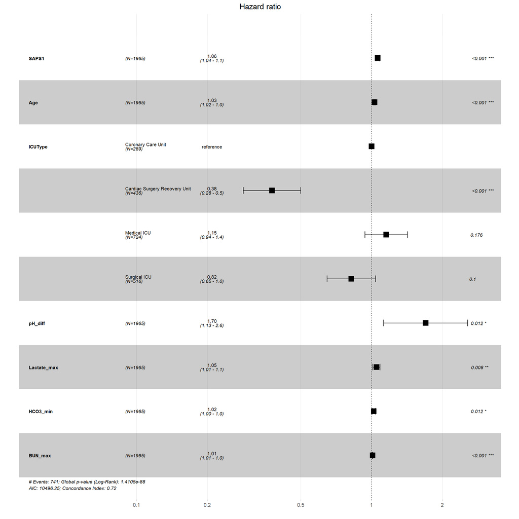

```r
survminer::ggforest(cox.mv2, data=ICUSurv)
```

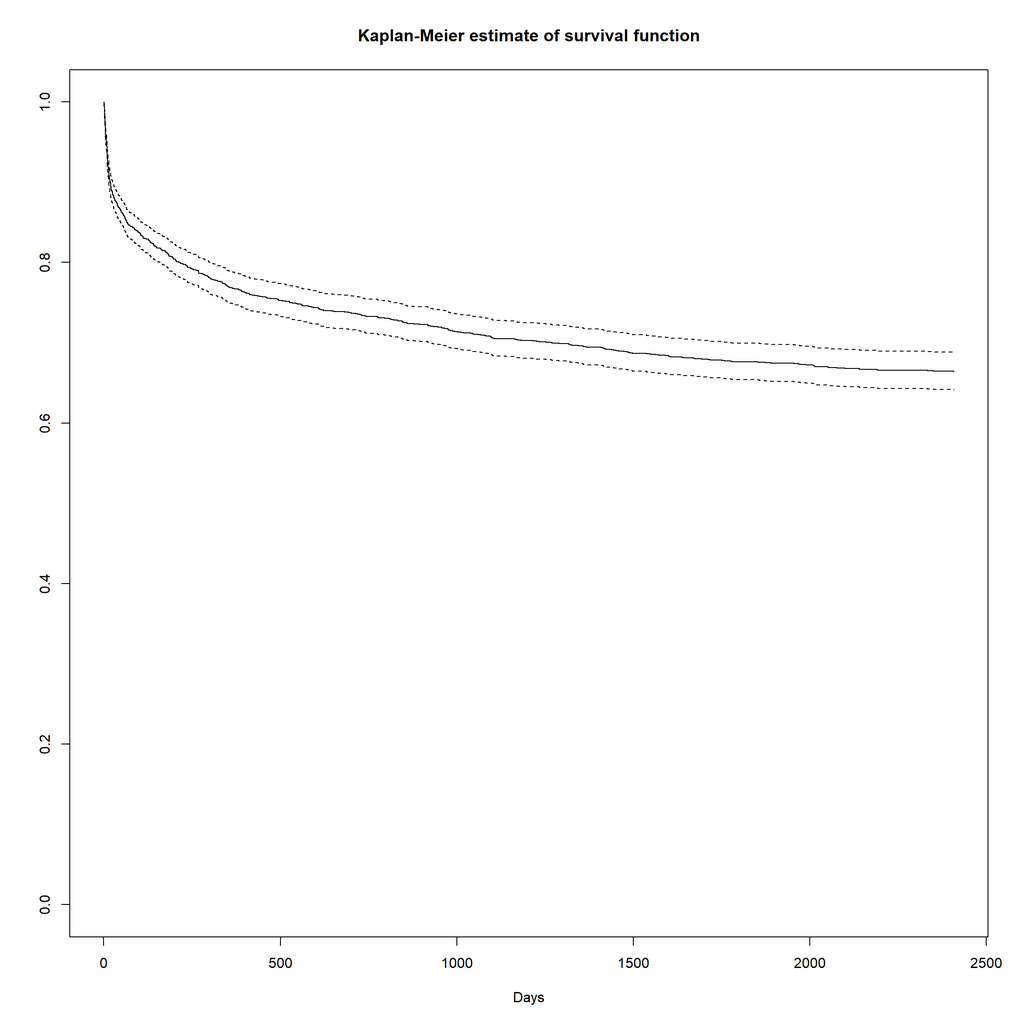

```r
# plot the Kaplan-Meier survival curve

fit.mv2 <- survfit(cox.mv2, data = ICUSurv)
plot(fit.mv2, main = "Kaplan-Meier estimate of survival function", xlab = "Days")
```

```r
#plot(fit.mv2, fun="cumhaz", main = "Nelson-Aalen estimate of cumulative hazard function", xlab = "Days")
```

```r
# Re-fit to the unseen data

cox.new <- coxph(Surv(Days, Status) ~ SAPS1 + Age + ICUType + pH_diff + Lactate_max + HCO3_min + BUN_max, data = icu_patients_df1)
summary(cox.new)
```

```
## Call:
## coxph(formula = Surv(Days, Status) ~ SAPS1 + Age + ICUType +
##     pH_diff + Lactate_max + HCO3_min + BUN_max, data = icu_patients_df1)
##
##   n= 1965, number of events= 741
##    (96 observations deleted due to missingness)
##
##                                           coef exp(coef)  se(coef)      z Pr(>|z|)
## SAPS1                                 0.060363  1.062222  0.008464  7.131 9.94e-13 ***
## Age                                   0.028492  1.028902  0.002639 10.797  < 2e-16 ***
## ICUTypeCardiac Surgery Recovery Unit -0.974935  0.377217  0.143203 -6.808 9.89e-12 ***
## ICUTypeMedical ICU                    0.143615  1.154440  0.106124  1.353  0.17597
## ICUTypeSurgical ICU                  -0.198822  0.819696  0.120951 -1.644  0.10021
## pH_diff                               0.529524  1.698124  0.210009  2.521  0.01169 *
## Lactate_max                           0.048192  1.049372  0.018042  2.671  0.00756 **
## HCO3_min                              0.020940  1.021161  0.008286  2.527  0.01150 *
## BUN_max                               0.009746  1.009794  0.001484  6.566 5.15e-11 ***
## ---
## Signif. codes:  0 '***' 0.001 '**' 0.01 '*' 0.05 '.' 0.1 ' ' 1
##
##                                      exp(coef) exp(-coef) lower .95 upper .95
## SAPS1                                   1.0622     0.9414    1.0447    1.0800
## Age                                     1.0289     0.9719    1.0236    1.0342
## ICUTypeCardiac Surgery Recovery Unit    0.3772     2.6510    0.2849    0.4994
## ICUTypeMedical ICU                      1.1544     0.8662    0.9376    1.4214
## ICUTypeSurgical ICU                     0.8197     1.2200    0.6467    1.0390
## pH_diff                                 1.6981     0.5889    1.1251    2.5629
## Lactate_max                             1.0494     0.9530    1.0129    1.0871
## HCO3_min                                1.0212     0.9793    1.0047    1.0379
## BUN_max                                 1.0098     0.9903    1.0069    1.0127
##
## Concordance= 0.719  (se = 0.009 )
## Likelihood ratio test= 437.4  on 9 df,   p=<2e-16
## Wald test            = 417.5  on 9 df,   p=<2e-16
## Score (logrank) test = 448.8  on 9 df,   p=<2e-16
```

```r
extractAIC(cox.new)
```

```
## [1]     9.00 10496.25
```

### Task 2 Part 6

Diagnostic statistics. Assess the proportional hazards assumption and linearity assumptions.

```r
# Diagnostic statistics:

# Assessing the proportional hazards assumption:
# testing for proportional hazards assumption using cox.zph()
prop.mv2 <- cox.zph(cox.mv2)
prop.mv2
```

```
##                                           rho    chisq        p
## SAPS1                                -0.11560 10.48006 1.21e-03
## Age                                   0.04325  1.38215 2.40e-01
## ICUTypeCardiac Surgery Recovery Unit  0.10195  8.10121 4.42e-03
## ICUTypeMedical ICU                    0.00988  0.07320 7.87e-01
## ICUTypeSurgical ICU                  -0.01327  0.13415 7.14e-01
## pH_diff                               0.03862  1.01119 3.15e-01
## Lactate_max                          -0.09583  8.92616 2.81e-03
## HCO3_min                              0.09110  7.24252 7.12e-03
## BUN_max                               0.00375  0.00945 9.23e-01
## GLOBAL                                     NA 62.24086 4.95e-10
```

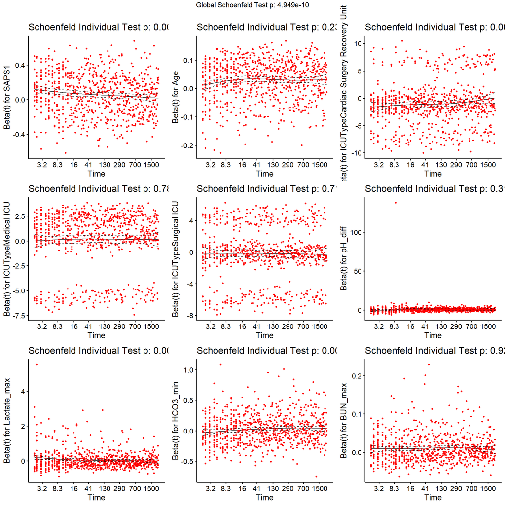

```r
# scaled Schoenfeld residuals against the transformed time
ggcoxzph(prop.mv2)
```

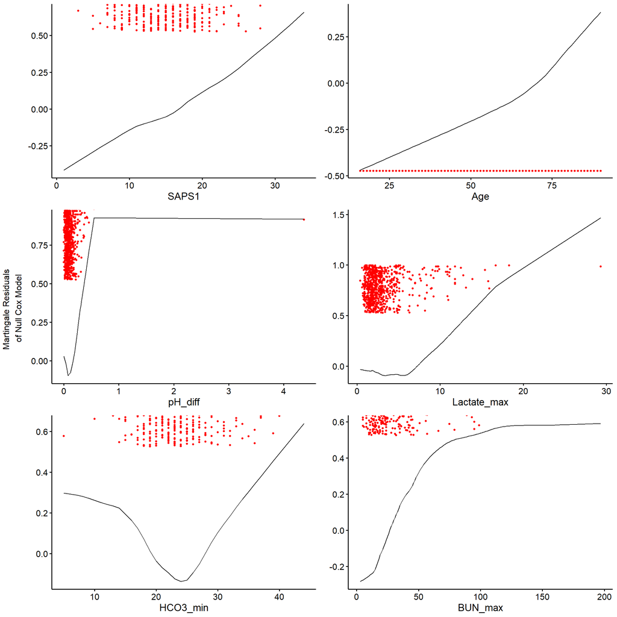

```r
# Assessing linearity: assume that continuous covariates have a linear form
# plot the Martingale residuals against continuous covariates can be used to detect nonlinearity
# graphs of continuous covariates against martingale residuals of null cox proportional hazards model
ggcoxfunctional(Surv(Days, Status) ~ SAPS1 + Age + pH_diff + Lactate_max + HCO3_min + BUN_max, data = ICUSurv, iter = 5)
```

A significant P value indicates that the proportional hazards assumption is violated for that covariate. The output from the proportional hazards test shows that the test is statistically significant for SAPS1, ICUType, Lactate_max and HCO3_min (but not for any other covariates). The global test is also statistically significant (p-value = 4.95e-10). Therefore, there appears to be a violation of the proportional hazards model.

We also see there is a linearity issue particularly with the HCO3_min. SAPS1 and Age are very linear, and we can see some linearity for pH_diff, Lactate_max and BUN_max. This non-linearity is probably because both low and high values of HCO3 may have an effect on survival.

To resolve this, we will add covariate x time interaction to resolve violations of the proportional hazards assumption From the plots, we can see a potential time cut at around 41 days. We will choose 42 days, since it is the answer to the meaning of life, the universe, and everything.

We will also try a model without the HCO3 covariate.

```r
# splitting the old dataset to two time intervals at 42 days
icu.split <- survSplit( Surv(Days, Status) ~ ., data = ICUSurv, cut=c(42), episode= "tgroup")
# fitting Cox multivariable model to the new dataset
cox.mv4 <- coxph( Surv(Days, Status) ~ SAPS1:strata(tgroup) + Age + ICUType:strata(tgroup) + pH_diff + Lactate_max:strata(tgroup) + HCO3_min:strata(tgroup) + BUN_max, data = icu.split)
summary(cox.mv4)
```

```
## Call:
## coxph(formula = Surv(Days, Status) ~ SAPS1:strata(tgroup) + Age +
##     ICUType:strata(tgroup) + pH_diff + Lactate_max:strata(tgroup) +
##     HCO3_min:strata(tgroup) + BUN_max, data = icu.split)
##
##   n= 3603, number of events= 741
##
##                                                                  coef exp(coef)  se(coef)      z Pr(>|z|)
## Age                                                          0.027877  1.028270  0.002626 10.617  < 2e-16 ***
## pH_diff                                                      0.432229  1.540688  0.225372  1.918 0.055131 .
## BUN_max                                                      0.009621  1.009668  0.001490  6.457 1.07e-10 ***
## SAPS1:strata(tgroup)tgroup=1                                 0.076535  1.079540  0.012256  6.245 4.25e-10 ***
## SAPS1:strata(tgroup)tgroup=2                                 0.044502  1.045507  0.011386  3.909 9.28e-05 ***
## strata(tgroup)tgroup=1:ICUTypeCardiac Surgery Recovery Unit -1.429041  0.239538  0.252795 -5.653 1.58e-08 ***
## strata(tgroup)tgroup=2:ICUTypeCardiac Surgery Recovery Unit -0.724440  0.484596  0.176478 -4.105 4.04e-05 ***
## strata(tgroup)tgroup=1:ICUTypeMedical ICU                    0.235489  1.265528  0.159354  1.478 0.139469
## strata(tgroup)tgroup=2:ICUTypeMedical ICU                    0.078609  1.081781  0.141471  0.556 0.578446
## strata(tgroup)tgroup=1:ICUTypeSurgical ICU                  -0.113694  0.892531  0.181037 -0.628 0.529993
## strata(tgroup)tgroup=2:ICUTypeSurgical ICU                  -0.267666  0.765163  0.159802 -1.675 0.093937 .
## strata(tgroup)tgroup=1:Lactate_max                           0.080435  1.083758  0.021433  3.753 0.000175 ***
## strata(tgroup)tgroup=2:Lactate_max                          -0.024515  0.975783  0.030472 -0.805 0.421107
## strata(tgroup)tgroup=1:HCO3_min                             -0.001128  0.998873  0.012055 -0.094 0.925451
## strata(tgroup)tgroup=2:HCO3_min                              0.040367  1.041193  0.011049  3.653 0.000259 ***
## ---
## Signif. codes:  0 '***' 0.001 '**' 0.01 '*' 0.05 '.' 0.1 ' ' 1
##
##                                                             exp(coef) exp(-coef) lower .95 upper .95
## Age                                                            1.0283     0.9725    1.0230    1.0336
## pH_diff                                                        1.5407     0.6491    0.9906    2.3964
## BUN_max                                                        1.0097     0.9904    1.0067    1.0126
## SAPS1:strata(tgroup)tgroup=1                                   1.0795     0.9263    1.0539    1.1058
## SAPS1:strata(tgroup)tgroup=2                                   1.0455     0.9565    1.0224    1.0691
## strata(tgroup)tgroup=1:ICUTypeCardiac Surgery Recovery Unit    0.2395     4.1747    0.1459    0.3931
## strata(tgroup)tgroup=2:ICUTypeCardiac Surgery Recovery Unit    0.4846     2.0636    0.3429    0.6849
## strata(tgroup)tgroup=1:ICUTypeMedical ICU                      1.2655     0.7902    0.9260    1.7295
## strata(tgroup)tgroup=2:ICUTypeMedical ICU                      1.0818     0.9244    0.8198    1.4274
## strata(tgroup)tgroup=1:ICUTypeSurgical ICU                     0.8925     1.1204    0.6259    1.2727
## strata(tgroup)tgroup=2:ICUTypeSurgical ICU                     0.7652     1.3069    0.5594    1.0466
## strata(tgroup)tgroup=1:Lactate_max                             1.0838     0.9227    1.0392    1.1303
## strata(tgroup)tgroup=2:Lactate_max                             0.9758     1.0248    0.9192    1.0358
## strata(tgroup)tgroup=1:HCO3_min                                0.9989     1.0011    0.9755    1.0228
## strata(tgroup)tgroup=2:HCO3_min                                1.0412     0.9604    1.0189    1.0640
##
## Concordance= 0.728  (se = 0.009 )
## Likelihood ratio test= 483.5  on 15 df,   p=<2e-16
## Wald test            = 472.6  on 15 df,   p=<2e-16
## Score (logrank) test = 507.7  on 15 df,   p=<2e-16
```

```r
# evaluating the proportional hazards assumption
prop.mv4 <- cox.zph(cox.mv4)
prop.mv4
```

```
##                                                                   rho    chisq      p
## Age                                                          0.037528 1.04e+00 0.3085
## pH_diff                                                      0.017166 2.29e-01 0.6320
## BUN_max                                                      0.000261 4.61e-05 0.9946
## SAPS1:strata(tgroup)tgroup=1                                -0.019037 2.73e-01 0.6014
## SAPS1:strata(tgroup)tgroup=2                                -0.058565 2.72e+00 0.0993
## strata(tgroup)tgroup=1:ICUTypeCardiac Surgery Recovery Unit  0.003211 8.18e-03 0.9280
## strata(tgroup)tgroup=2:ICUTypeCardiac Surgery Recovery Unit  0.046112 1.60e+00 0.2061
## strata(tgroup)tgroup=1:ICUTypeMedical ICU                    0.013722 1.45e-01 0.7033
## strata(tgroup)tgroup=2:ICUTypeMedical ICU                    0.030049 6.70e-01 0.4129
## strata(tgroup)tgroup=1:ICUTypeSurgical ICU                   0.000984 7.36e-04 0.9784
## strata(tgroup)tgroup=2:ICUTypeSurgical ICU                   0.003578 9.59e-03 0.9220
## strata(tgroup)tgroup=1:Lactate_max                          -0.000142 1.87e-05 0.9966
## strata(tgroup)tgroup=2:Lactate_max                          -0.017903 2.75e-01 0.5997
## strata(tgroup)tgroup=1:HCO3_min                              0.012103 1.22e-01 0.7266
## strata(tgroup)tgroup=2:HCO3_min                              0.013122 1.50e-01 0.6990
## GLOBAL                                                             NA 7.05e+00 0.9562
```

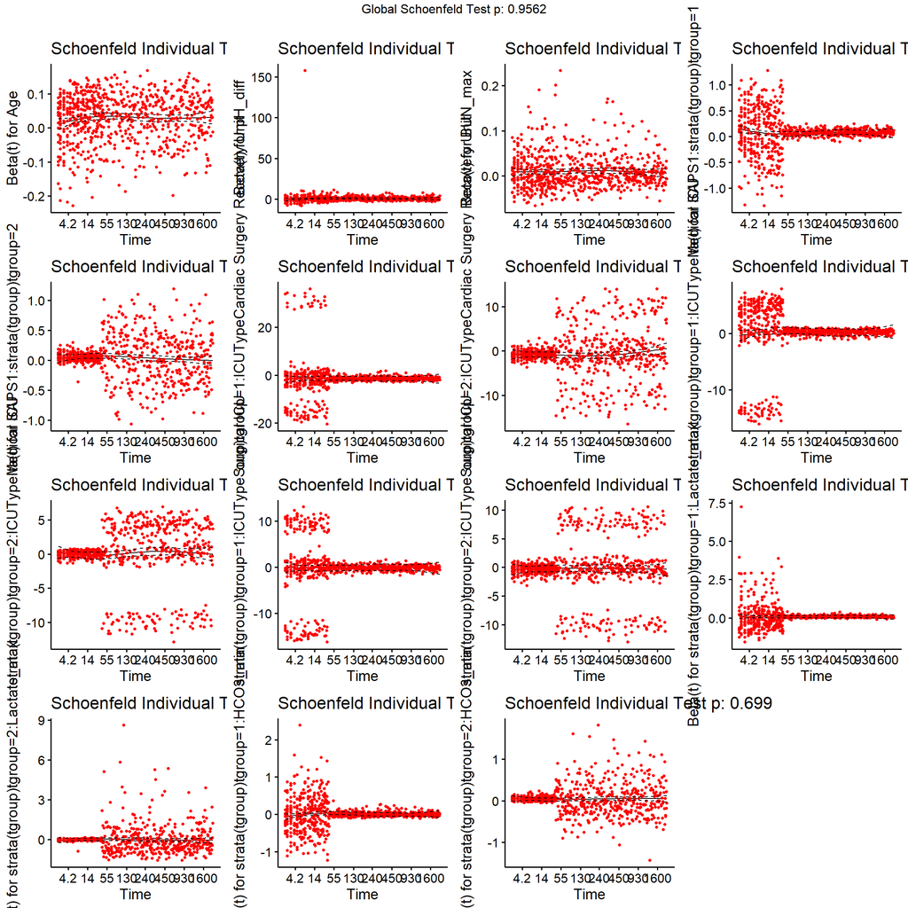

```r
ggcoxzph(prop.mv4)
```

```r
cox.mv5 <- coxph( Surv(Days, Status) ~ SAPS1:strata(tgroup) + Age + ICUType:strata(tgroup) + pH_diff + Lactate_max:strata(tgroup) + BUN_max, data = icu.split)
summary(cox.mv5)
```

```
## Call:
## coxph(formula = Surv(Days, Status) ~ SAPS1:strata(tgroup) + Age +
##     ICUType:strata(tgroup) + pH_diff + Lactate_max:strata(tgroup) +
##     BUN_max, data = icu.split)
##
##   n= 3603, number of events= 741
##
##                                                                  coef exp(coef)  se(coef)      z Pr(>|z|)
## Age                                                          0.028798  1.029217  0.002606 11.050  < 2e-16 ***
## pH_diff                                                      0.434514  1.544212  0.227322  1.911  0.05595 .
## BUN_max                                                      0.008837  1.008876  0.001445  6.116 9.59e-10 ***
## SAPS1:strata(tgroup)tgroup=1                                 0.077394  1.080468  0.011831  6.541 6.10e-11 ***
## SAPS1:strata(tgroup)tgroup=2                                 0.034883  1.035498  0.011036  3.161  0.00157 **
## strata(tgroup)tgroup=1:ICUTypeCardiac Surgery Recovery Unit -1.441696  0.236526  0.252306 -5.714 1.10e-08 ***
## strata(tgroup)tgroup=2:ICUTypeCardiac Surgery Recovery Unit -0.697248  0.497954  0.175495 -3.973 7.10e-05 ***
## strata(tgroup)tgroup=1:ICUTypeMedical ICU                    0.247131  1.280346  0.159110  1.553  0.12037
## strata(tgroup)tgroup=2:ICUTypeMedical ICU                    0.056348  1.057966  0.141427  0.398  0.69032
## strata(tgroup)tgroup=1:ICUTypeSurgical ICU                  -0.116681  0.889869  0.180736 -0.646  0.51855
## strata(tgroup)tgroup=2:ICUTypeSurgical ICU                  -0.244212  0.783321  0.159365 -1.532  0.12542
## strata(tgroup)tgroup=1:Lactate_max                           0.081034  1.084407  0.020489  3.955 7.65e-05 ***
## strata(tgroup)tgroup=2:Lactate_max                          -0.046852  0.954228  0.029912 -1.566  0.11727
## ---
## Signif. codes:  0 '***' 0.001 '**' 0.01 '*' 0.05 '.' 0.1 ' ' 1
##
##                                                             exp(coef) exp(-coef) lower .95 upper .95
## Age                                                            1.0292     0.9716    1.0240    1.0345
## pH_diff                                                        1.5442     0.6476    0.9890    2.4110
## BUN_max                                                        1.0089     0.9912    1.0060    1.0117
## SAPS1:strata(tgroup)tgroup=1                                   1.0805     0.9255    1.0557    1.1058
## SAPS1:strata(tgroup)tgroup=2                                   1.0355     0.9657    1.0133    1.0581
## strata(tgroup)tgroup=1:ICUTypeCardiac Surgery Recovery Unit    0.2365     4.2279    0.1442    0.3878
## strata(tgroup)tgroup=2:ICUTypeCardiac Surgery Recovery Unit    0.4980     2.0082    0.3530    0.7024
## strata(tgroup)tgroup=1:ICUTypeMedical ICU                      1.2803     0.7810    0.9373    1.7489
## strata(tgroup)tgroup=2:ICUTypeMedical ICU                      1.0580     0.9452    0.8018    1.3959
## strata(tgroup)tgroup=1:ICUTypeSurgical ICU                     0.8899     1.1238    0.6244    1.2681
## strata(tgroup)tgroup=2:ICUTypeSurgical ICU                     0.7833     1.2766    0.5732    1.0705
## strata(tgroup)tgroup=1:Lactate_max                             1.0844     0.9222    1.0417    1.1288
## strata(tgroup)tgroup=2:Lactate_max                             0.9542     1.0480    0.8999    1.0118
##
## Concordance= 0.724  (se = 0.009 )
## Likelihood ratio test= 470.4  on 13 df,   p=<2e-16
## Wald test            = 457.2  on 13 df,   p=<2e-16
## Score (logrank) test = 490.2  on 13 df,   p=<2e-16
```

```r
extractAIC(cox.mv2)
```

```
## [1]     9.00 10496.25
```

```r
extractAIC(cox.mv4)
```

```
## [1]    15.00 10462.16
```

```r
extractAIC(cox.mv5)
```

```
## [1]    13.00 10471.22
```

```r
print(anova(cox.mv4, cox.mv5))
```

```
## Analysis of Deviance Table
##  Cox model: response is  Surv(Days, Status)
##  Model 1: ~ SAPS1:strata(tgroup) + Age + ICUType:strata(tgroup) + pH_diff + Lactate_max:strata(tgroup) + HCO3_min:strata(tgroup) + BUN_max
##  Model 2: ~ SAPS1:strata(tgroup) + Age + ICUType:strata(tgroup) + pH_diff + Lactate_max:strata(tgroup) + BUN_max
##    loglik  Chisq Df P(>|Chi|)
## 1 -5216.1
## 2 -5222.6 13.057  2  0.001461 **
## ---
## Signif. codes:  0 '***' 0.001 '**' 0.01 '*' 0.05 '.' 0.1 ' ' 1
```

*Using this new stratified model (cox.mv4), the individual covariates no longer violate the proportional hazards assumption. Similarly the global test is no longer significant (p=0.9562) and thus the assumption holds for our new model.*

*Also we can see that this model has a lower AIC (10462.16 vs 10496.25), meaning that it is likely a better model in general.*

*However, this model is also a lot more difficult to interpret, and so whether we use it or not partially depends on whether we are aiming purely for prediction, or whether we care about interpretability.*

*Note - We see that the model without HCO3 (cox.mv5) is significantly different and has a higher AIC than cox.mv4, so we will not use that one.*

This our second final model is:

```r
summary(cox.mv4)
```

```
## Call:
## coxph(formula = Surv(Days, Status) ~ SAPS1:strata(tgroup) + Age +
##     ICUType:strata(tgroup) + pH_diff + Lactate_max:strata(tgroup) +
##     HCO3_min:strata(tgroup) + BUN_max, data = icu.split)
##
##   n= 3603, number of events= 741
##
##                                                                  coef exp(coef)  se(coef)      z Pr(>|z|)
## Age                                                          0.027877  1.028270  0.002626 10.617  < 2e-16 ***
## pH_diff                                                      0.432229  1.540688  0.225372  1.918 0.055131 .
## BUN_max                                                      0.009621  1.009668  0.001490  6.457 1.07e-10 ***
## SAPS1:strata(tgroup)tgroup=1                                 0.076535  1.079540  0.012256  6.245 4.25e-10 ***
## SAPS1:strata(tgroup)tgroup=2                                 0.044502  1.045507  0.011386  3.909 9.28e-05 ***
## strata(tgroup)tgroup=1:ICUTypeCardiac Surgery Recovery Unit -1.429041  0.239538  0.252795 -5.653 1.58e-08 ***
## strata(tgroup)tgroup=2:ICUTypeCardiac Surgery Recovery Unit -0.724440  0.484596  0.176478 -4.105 4.04e-05 ***
## strata(tgroup)tgroup=1:ICUTypeMedical ICU                    0.235489  1.265528  0.159354  1.478 0.139469
## strata(tgroup)tgroup=2:ICUTypeMedical ICU                    0.078609  1.081781  0.141471  0.556 0.578446
## strata(tgroup)tgroup=1:ICUTypeSurgical ICU                  -0.113694  0.892531  0.181037 -0.628 0.529993
## strata(tgroup)tgroup=2:ICUTypeSurgical ICU                  -0.267666  0.765163  0.159802 -1.675 0.093937 .
## strata(tgroup)tgroup=1:Lactate_max                           0.080435  1.083758  0.021433  3.753 0.000175 ***
## strata(tgroup)tgroup=2:Lactate_max                          -0.024515  0.975783  0.030472 -0.805 0.421107
## strata(tgroup)tgroup=1:HCO3_min                             -0.001128  0.998873  0.012055 -0.094 0.925451
## strata(tgroup)tgroup=2:HCO3_min                              0.040367  1.041193  0.011049  3.653 0.000259 ***
## ---
## Signif. codes:  0 '***' 0.001 '**' 0.01 '*' 0.05 '.' 0.1 ' ' 1
##
##                                                             exp(coef) exp(-coef) lower .95 upper .95
## Age                                                            1.0283     0.9725    1.0230    1.0336
## pH_diff                                                        1.5407     0.6491    0.9906    2.3964
## BUN_max                                                        1.0097     0.9904    1.0067    1.0126
## SAPS1:strata(tgroup)tgroup=1                                   1.0795     0.9263    1.0539    1.1058
## SAPS1:strata(tgroup)tgroup=2                                   1.0455     0.9565    1.0224    1.0691
## strata(tgroup)tgroup=1:ICUTypeCardiac Surgery Recovery Unit    0.2395     4.1747    0.1459    0.3931
## strata(tgroup)tgroup=2:ICUTypeCardiac Surgery Recovery Unit    0.4846     2.0636    0.3429    0.6849
## strata(tgroup)tgroup=1:ICUTypeMedical ICU                      1.2655     0.7902    0.9260    1.7295
## strata(tgroup)tgroup=2:ICUTypeMedical ICU                      1.0818     0.9244    0.8198    1.4274
## strata(tgroup)tgroup=1:ICUTypeSurgical ICU                     0.8925     1.1204    0.6259    1.2727
## strata(tgroup)tgroup=2:ICUTypeSurgical ICU                     0.7652     1.3069    0.5594    1.0466
## strata(tgroup)tgroup=1:Lactate_max                             1.0838     0.9227    1.0392    1.1303
## strata(tgroup)tgroup=2:Lactate_max                             0.9758     1.0248    0.9192    1.0358
## strata(tgroup)tgroup=1:HCO3_min                                0.9989     1.0011    0.9755    1.0228
## strata(tgroup)tgroup=2:HCO3_min                                1.0412     0.9604    1.0189    1.0640
##
## Concordance= 0.728  (se = 0.009 )
## Likelihood ratio test= 483.5  on 15 df,   p=<2e-16
## Wald test            = 472.6  on 15 df,   p=<2e-16
## Score (logrank) test = 507.7  on 15 df,   p=<2e-16
```

Further diagnostics for both models:

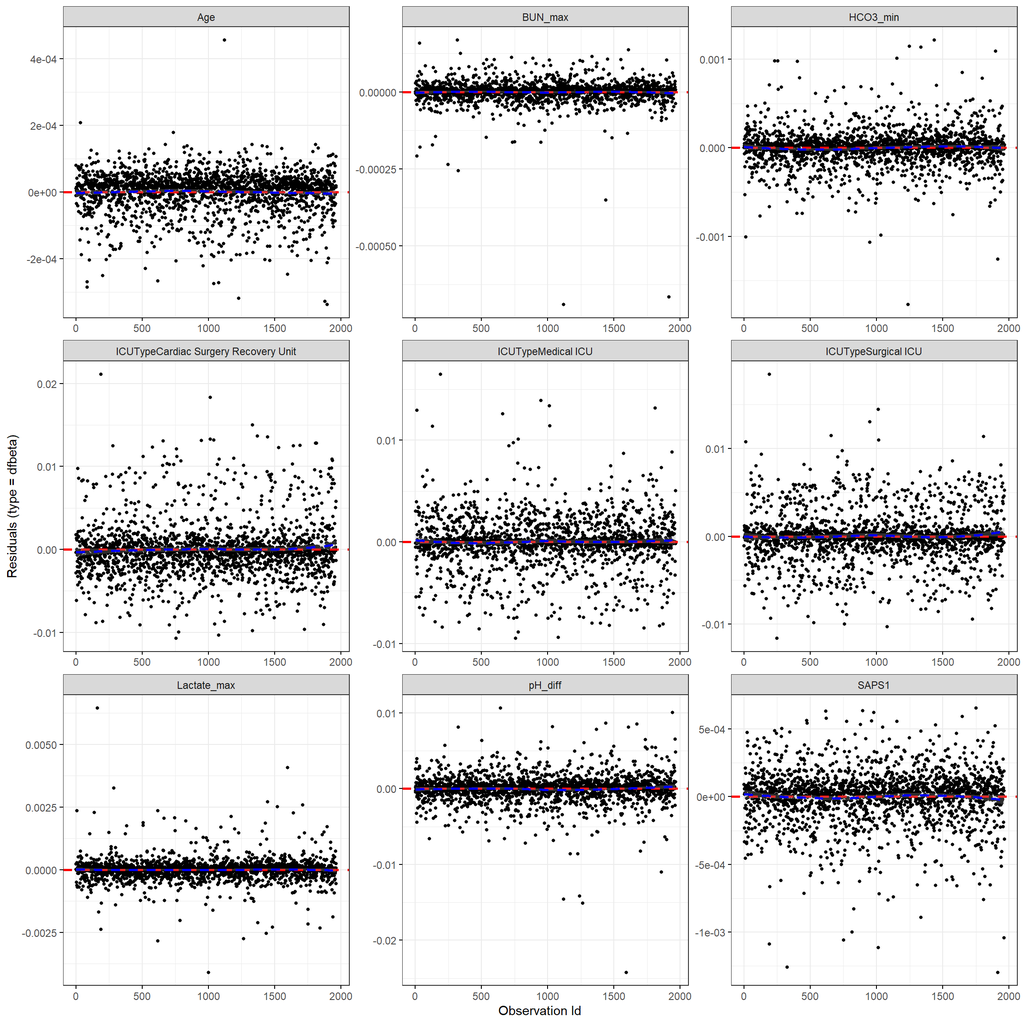

```r
# Testing influential observations:
# plots the estimated changes in the regression coefficients upon deleting each observation in turn
ggcoxdiagnostics(cox.mv2, type = "dfbeta",
                 linear.predictions = FALSE,
                 ggtheme = theme_bw())
```

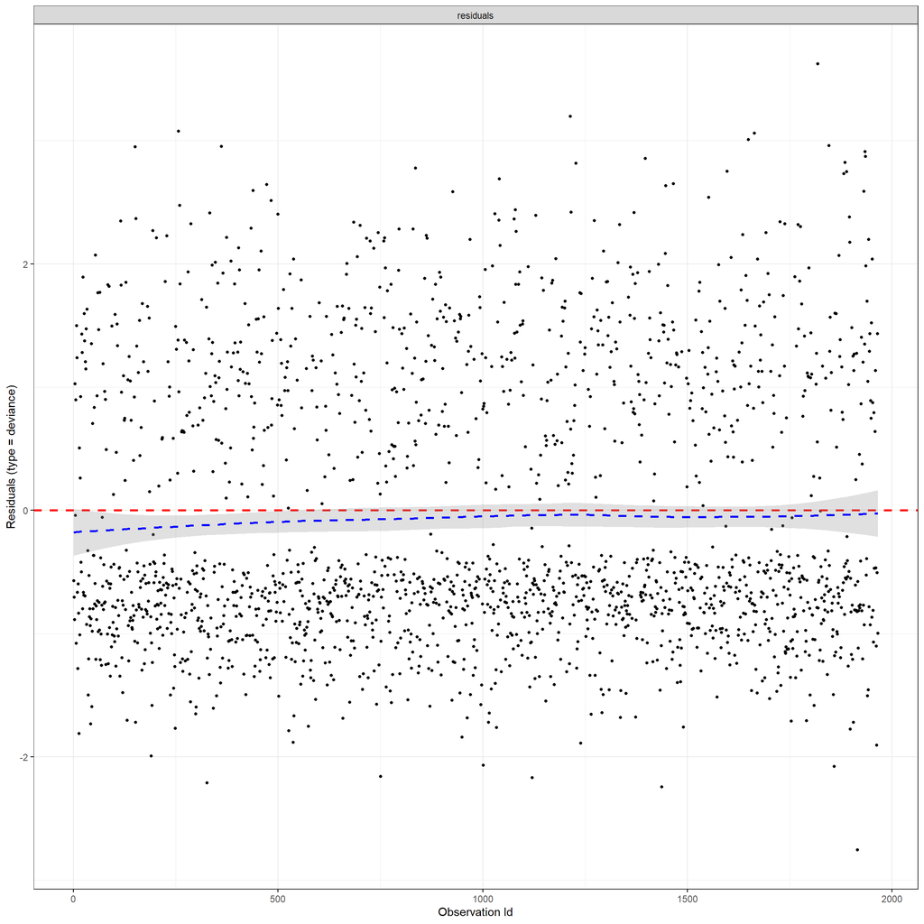

```r
# check outliers by visualizing the deviance residuals
# deviance residual is a normalized transform of the martingale residual
# residuals should be roughtly symmetrically distributed about zero with a standard deviation of 1.
ggcoxdiagnostics(cox.mv2, type = "deviance",
                 linear.predictions = FALSE,
                 ggtheme = theme_bw())
```

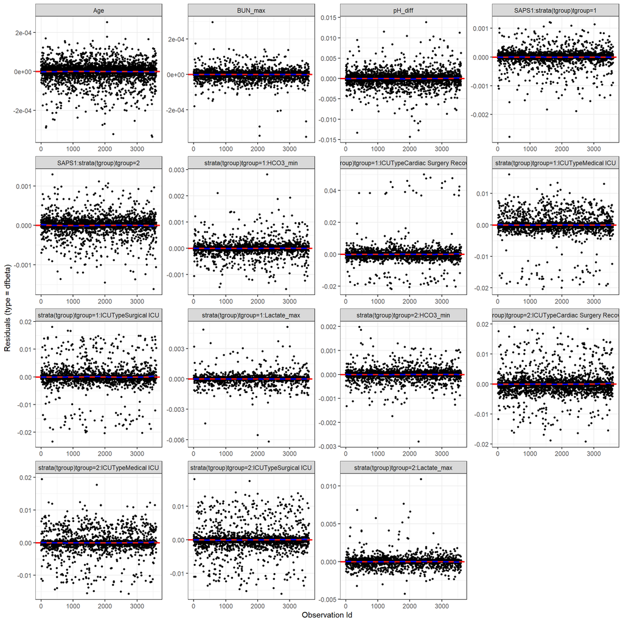

```r
# Positive values correspond to individuals that “died too soon” compared to expected survival times.
# Negative values correspond to individual that “lived too long”.


ggcoxdiagnostics(cox.mv4, type = "dfbeta",
                 linear.predictions = FALSE,
                 ggtheme = theme_bw())
```

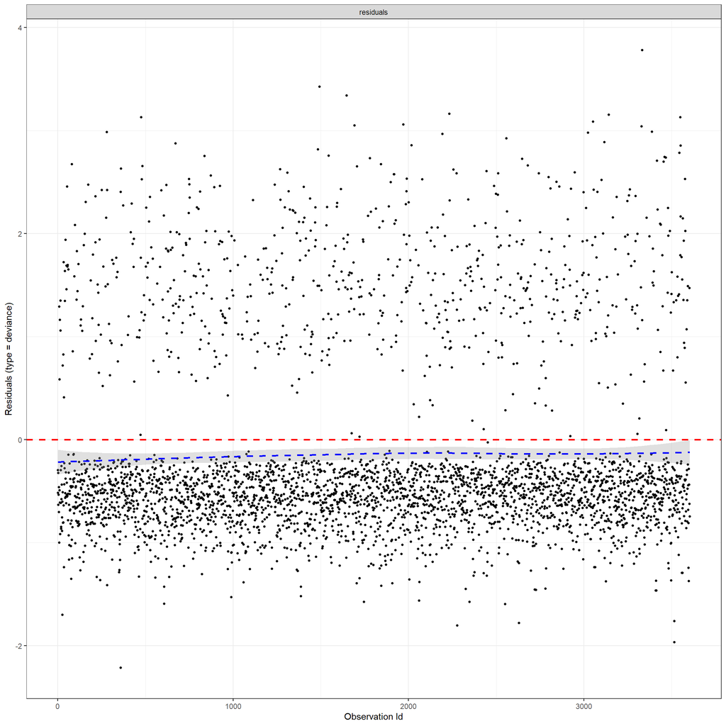

```r
# check outliers by visualizing the deviance residuals
# deviance residual is a normalized transform of the martingale residual
# residuals should be roughtly symmetrically distributed about zero with a standard deviation of 1.
ggcoxdiagnostics(cox.mv4, type = "deviance",
                 linear.predictions = FALSE,
                 ggtheme = theme_bw())
```

### Task 2 Part7

In regards to the model that includes a covariate x time interaction:

The p-value (<2e-16) for all three overall tests (likelihood ratio test, Wald test, and score test) are significant, indicating that the model is significant.

The reason a time interaction is needed is probably because the covariates being measured are good at predicting short term survival in the ICU. Patients who survive the initial acute period might have a completely different set of risk factors for survival.

If we do not use the time interaction, the model is still significant - p-value <2e-16 for all three overall tests (likelihood ratio test, Wald test, and score test). ICU Type of Cardiac Surgery Recovery Unit has a statistically significant hazard ratio 0.38 (longer survival). The other ICU Types do not have significant differences. The other covariates SAPS1, Age, pH_diff, Lactate_max, HCO3_min and BUN_max all have significant hazard ratios >1 (shorter survival). An example of interpreting these values - SAPS1 has a significant hazard ratio of 1.06, which means for every unit increase in the SAPS score, there is a 1.06 higher risk of death at any point in time. However, since the proportional hazards assumptions do not quite hold, we cannot be sure that this hazard ratio of 1.06 is the same for every time point - it just gives us an average over the entire time span.

The time interaction is useful here. In the covariate x time model, using the SAPS1 score as an example, before 42 days, there is a hazard ratio of 1.079 compared to a hazard ratio of 1.046 after 42 days.

## Save, knit and submit

**Reminder**: don’t forget to save this file, to knit it to check that everything works, and then submit via the drop box in Openlearning.

## Submit your assignment

When you have finished, and are satisfied with your assignment solutions, and this file knits without errors and the output looks the way you want, then you should submit via the drop box in Openlearning.

### Problems?

If you encounter problems with any part of the process described above, please contact the course instructor via OpenLearning as soon as possible so that the issues can be resolved in good time, and well before the assignment is due.

### Additional Information

Each task attracts the indicated number of marks (out of a total of 30 marks for the assignment). The instructions are deliberately open-ended and less prescriptive than the individual assignments to allow you some latitude in what you do and how you go about the task. However, to complete the tasks and gain full marks, you only need to replicate or repeat the steps covered in the course - if you do most or all of the things described in the revalant chapters of the HDAT9600 course, full marks wil be awarded.

Note also that with respect to the model fitting, there are no **right** or **wrong** answers when it comes to variable selection and other aspects of model specification. Deep understanding of the underlying medical concepts which govern patient treatment and outcomes in ICUs is not required or assumed, although you should try to gain some understanding of each variable using the links provided. You will not be marked down if your medical justifications are not exactly correct or complete, but do you best, and don’t hesitate to seek help from the course instructor.